# present

```python
# I have a tendency to import everthing on the planet so I hope u have ram

import pandas as pd
import numpy as np
import matplotlib.pyplot as plt
import tensorflow as tf
from tensorflow import keras
from tensorflow.keras import layers
from tensorflow.keras.layers import Input, Concatenate, Dense, Flatten, Dropout, BatchNormalization, Conv2D, MaxPooling2D, GlobalAveragePooling2D
from tensorflow.keras.models import Sequential, Model
from tensorflow.keras.optimizers import Adam
from tensorflow.keras.preprocessing import image
from tensorflow.keras.preprocessing.image import ImageDataGenerator, img_to_array, load_img
from tensorflow.keras.applications import ResNet50
from keras.losses import MeanSquaredError

import keras_tuner as kt

from tensorflow.keras.callbacks import ModelCheckpoint
from tensorflow.keras.models import load_model
from sklearn.model_selection import train_test_split
import numpy as np
import pandas as pd
import os

from sklearn.utils.class_weight import compute_class_weight

from sklearn.metrics import confusion_matrix, ConfusionMatrixDisplay
import seaborn as sns
```

#### Load our data into a pandas df either from csv or excel

```python
df = pd.read_csv('Path1/Path1-Model Training/Path1 Challenge Training Data.csv')

directory = 'Path1/Path1-Model Training/Path1 Challenge Training Images/'
```

```python
# outdated data
# df = pd.read_excel('Path1/Path1-Model Training/Path1 Challenge Training Data.xlsx')
# df = df[df['Grade Category'] ! =  'Standard']

# directory = 'Path1/Path1-Model Training/Path1 Challenge Training Images/'
```

```python
df.head()
```

|  | Filename | Carcass_ID | Score | Grade Category |
| --- | --- | --- | --- | --- |
| 0 | 00000002-1.tif | 2 | 526.7 | Select |
| 1 | 00000003-1.tif | 3 | 320.0 | Select |
| 2 | 00000004-1.tif | 4 | 453.3 | Select |
| 3 | 00000005-1.tif | 5 | 566.7 | Select |
| 4 | 00000006-1.tif | 6 | 406.7 | Select |

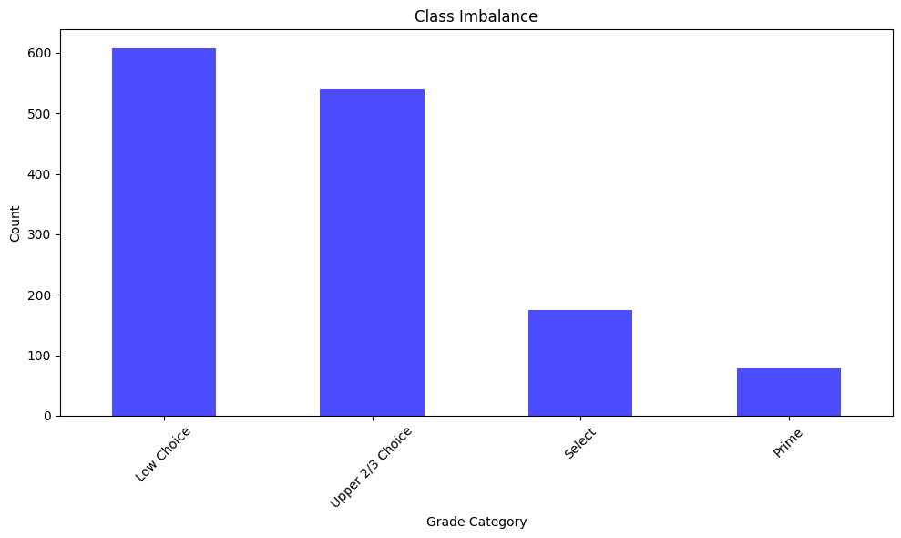

```python
# lets check our balance
class_counts = df['Grade Category'].value_counts()
#print(class_counts)

plt.figure(figsize = (10, 6))
class_counts.plot(kind = 'bar', color = 'blue', alpha  =  0.7)
plt.xlabel('Grade Category')
plt.ylabel('Count')
plt.title('Class Imbalance')
plt.xticks(rotation = 45)
plt.tight_layout()
plt.show()
```

## UH OH!

This stuff is so imbalanced.. what should we do?

Class weights: incentive/bonuses to network to focus on the smaller classes

Undersampling: Reduce samples from larger classes to even the playing field

Oversampling: Create artificial samples of underepresented classes. Synthetic Minority Over-sampling Technique or (SMOTE) can be done with either images or conventional data. This technique would generate new data values that exist within the range of existing classes.

In our data today I try our luck at avoiding imabalanced data issues, by relying on the neural networks ability to properly detect the patterns regardless of how much they are represented.

This isn't as dumb as it sounds, because we can implement some regularization techniques like dropout layers.

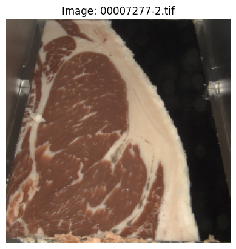

```
Low Choice
```

```python
ith_image = 547

image_filename = df['Filename'].iloc[ith_image]

image_path = os.path.join(directory, image_filename)

# plot
img = image.load_img(image_path, target_size = (224, 224))
plt.imshow(img)
plt.axis('off')
plt.title(f"Image: {image_filename}")
plt.show()

print(df['Grade Category'].iloc[ith_image])
```

### Split the data frame up

```python
train_data, validation_data = train_test_split(df, test_size = 0.2, random_state = 42)
```

### These are data generators

They will convert our dataframe data into images, and then the images into the tensors for the neural network

```python
datagen = ImageDataGenerator(
    rescale = 1./255 #normalization
    # this is where augmentation would occur. we found this to be harmful to our model because all beef pictures are from the same angle
)

batch_size = 32 # do you guys remember batch size?
# it is the amount of data points utilized during a training epoch

train_generator = datagen.flow_from_dataframe(
    dataframe = train_data,
    directory = directory,
    x_col = 'Filename',
    y_col = 'Grade Category',
    target_size = (224, 224),
    color_mode = 'rgb',
    batch_size = batch_size,
    class_mode = 'categorical',
    shuffle = True
)

validation_generator = datagen.flow_from_dataframe(
    dataframe = validation_data,
    directory = directory,
    x_col = 'Filename',
    y_col = 'Grade Category',
    target_size = (224, 224),
    color_mode = 'rgb',
    batch_size = batch_size,
    class_mode = 'categorical',
    shuffle = False
)
```

```
Found 1120 validated image filenames belonging to 4 classes.
Found 281 validated image filenames belonging to 4 classes.
```

```python
model = Sequential()

model.add(Conv2D(32, (3, 3), activation = 'relu', input_shape = (224, 224, 3)))
model.add(MaxPooling2D((2, 2)))

model.add(Conv2D(64, (3, 3), activation = 'relu'))
model.add(MaxPooling2D((2, 2)))

model.add(Conv2D(128, (3, 3), activation = 'relu'))

model.add(Flatten())
model.add(Dropout(0.5)) # this dropout layer randomly sets some inputs to 0 within the batch similarly to L1 and L2
# this helps prevent overfitting by forcing the neural network to look at new areas within the data and generalize

model.add(Dense(256, activation = 'relu') )
model.add(Dense(4, activation = 'softmax'))
```

#### What is a convolutional layer?

These are the layers where each node corresponds to a pattern. The first patterns are very simple, and through each layer they combine

#### What would need to change to create this into a regression problem?

```python
model.summary()
```

```
Model: "sequential_5"
```

```
┏━━━━━━━━━━━━━━━━━━━━━━━━━━━━━━━━━┳━━━━━━━━━━━━━━━━━━━━━━━━┳━━━━━━━━━━━━━━━┓
┃ Layer (type)                    ┃ Output Shape           ┃       Param # ┃
┡━━━━━━━━━━━━━━━━━━━━━━━━━━━━━━━━━╇━━━━━━━━━━━━━━━━━━━━━━━━╇━━━━━━━━━━━━━━━┩
│ conv2d_13 (Conv2D)              │ (None, 222, 222, 32)   │           896 │
├─────────────────────────────────┼────────────────────────┼───────────────┤
│ max_pooling2d_9 (MaxPooling2D)  │ (None, 111, 111, 32)   │             0 │
├─────────────────────────────────┼────────────────────────┼───────────────┤
│ conv2d_14 (Conv2D)              │ (None, 109, 109, 64)   │        18,496 │
├─────────────────────────────────┼────────────────────────┼───────────────┤
│ max_pooling2d_10 (MaxPooling2D) │ (None, 54, 54, 64)     │             0 │
├─────────────────────────────────┼────────────────────────┼───────────────┤
│ conv2d_15 (Conv2D)              │ (None, 52, 52, 128)    │        73,856 │
├─────────────────────────────────┼────────────────────────┼───────────────┤
│ flatten_4 (Flatten)             │ (None, 346112)         │             0 │
├─────────────────────────────────┼────────────────────────┼───────────────┤
│ dropout_5 (Dropout)             │ (None, 346112)         │             0 │
├─────────────────────────────────┼────────────────────────┼───────────────┤
│ dense_7 (Dense)                 │ (None, 256)            │    88,604,928 │
├─────────────────────────────────┼────────────────────────┼───────────────┤
│ dense_8 (Dense)                 │ (None, 4)              │         1,028 │
└─────────────────────────────────┴────────────────────────┴───────────────┘
```

```
 Total params: 88,699,204 (338.36 MB)
```

```
 Trainable params: 88,699,204 (338.36 MB)
```

```
 Non-trainable params: 0 (0.00 B)
```

```python
model.compile(optimizer = 'adam', loss = 'categorical_crossentropy', metrics = ['accuracy'])
checkpoint = ModelCheckpoint("coen.keras", monitor = "val_loss", verbose = 1, save_best_only = True)
```

# Why did we use categorical crossentropy?

That is because each class is equally distant from eachother. Lets our multi-classifier behave more similarly to a binary classifier

```python
# TTRAINNNN
history = model.fit(
    train_generator,
    steps_per_epoch = batch_size,
    epochs = 8,
    validation_data = validation_generator,
    validation_steps = batch_size,
    callbacks = [checkpoint]
)

# eval on validation
loss, accuracy = model.evaluate(validation_generator, verbose = 1)
print(f"Validation Loss: {loss}")
print(f"Validation Accuracy: {accuracy}")
```

```
32/32 ━━━━━━━━━━━━━━━━━━━━ 0s 990ms/step - accuracy: 0.4235 - loss: 4.3197
Epoch 1: val_loss improved from inf to 0.38808, saving model to coen.keras
```

[output not shown]

```
32/32 ━━━━━━━━━━━━━━━━━━━━ 50s 1s/step - accuracy: 0.4272 - loss: 4.2543 - val_accuracy: 0.8648 - val_loss: 0.3881
 3/32 ━━━━━━━━━━━━━━━━━━━━ 27s 942ms/step - accuracy: 0.8056 - loss: 0.4353
Epoch 2: val_loss improved from 0.38808 to 0.33876, saving model to coen.keras
32/32 ━━━━━━━━━━━━━━━━━━━━ 13s 392ms/step - accuracy: 0.8496 - loss: 0.3149 - val_accuracy: 0.8790 - val_loss: 0.3388
32/32 ━━━━━━━━━━━━━━━━━━━━ 0s 933ms/step - accuracy: 0.8856 - loss: 0.2969
Epoch 3: val_loss improved from 0.33876 to 0.17619, saving model to coen.keras
32/32 ━━━━━━━━━━━━━━━━━━━━ 43s 1s/step - accuracy: 0.8857 - loss: 0.2959 - val_accuracy: 0.9359 - val_loss: 0.1762
 3/32 ━━━━━━━━━━━━━━━━━━━━ 24s 859ms/step - accuracy: 0.9253 - loss: 0.1618
Epoch 4: val_loss improved from 0.17619 to 0.15297, saving model to coen.keras
32/32 ━━━━━━━━━━━━━━━━━━━━ 13s 383ms/step - accuracy: 0.9175 - loss: 0.1377 - val_accuracy: 0.9217 - val_loss: 0.1530
32/32 ━━━━━━━━━━━━━━━━━━━━ 0s 910ms/step - accuracy: 0.9515 - loss: 0.1215
Epoch 5: val_loss improved from 0.15297 to 0.12975, saving model to coen.keras
32/32 ━━━━━━━━━━━━━━━━━━━━ 42s 1s/step - accuracy: 0.9517 - loss: 0.1210 - val_accuracy: 0.9431 - val_loss: 0.1297
 3/32 ━━━━━━━━━━━━━━━━━━━━ 25s 875ms/step - accuracy: 0.9549 - loss: 0.1046
Epoch 6: val_loss did not improve from 0.12975
32/32 ━━━━━━━━━━━━━━━━━━━━ 6s 166ms/step - accuracy: 0.9580 - loss: 0.1092 - val_accuracy: 0.9324 - val_loss: 0.1311
32/32 ━━━━━━━━━━━━━━━━━━━━ 0s 950ms/step - accuracy: 0.9864 - loss: 0.0468
Epoch 7: val_loss improved from 0.12975 to 0.11028, saving model to coen.keras
32/32 ━━━━━━━━━━━━━━━━━━━━ 44s 1s/step - accuracy: 0.9865 - loss: 0.0465 - val_accuracy: 0.9466 - val_loss: 0.1103
 3/32 ━━━━━━━━━━━━━━━━━━━━ 28s 979ms/step - accuracy: 0.9913 - loss: 0.0322
Epoch 8: val_loss did not improve from 0.11028
32/32 ━━━━━━━━━━━━━━━━━━━━ 6s 178ms/step - accuracy: 0.9897 - loss: 0.0195 - val_accuracy: 0.9431 - val_loss: 0.1124
9/9 ━━━━━━━━━━━━━━━━━━━━ 4s 377ms/step - accuracy: 0.9542 - loss: 0.0998
Validation Loss: 0.12488292157649994
Validation Accuracy: 0.9430605173110962
```

```python
model_path = 'C:/Users/coenp/Documents/CS345/usda/coen.keras'
model = load_model(model_path)
```

```python
class_names = list(validation_generator.class_indices.keys())
class_indices = list(validation_generator.class_indices.values())

for idx, name in zip(class_indices, class_names):
    print(f"Class index {idx} corresponds to {name}")
```

```
Class index 0 corresponds to Low Choice
Class index 1 corresponds to Prime
Class index 2 corresponds to Select
Class index 3 corresponds to Upper 2/3 Choice
```

```python
y_pred = model.predict(validation_generator)
predicted_classes = np.argmax(y_pred, axis = 1)
print(predicted_classes)

true_labels = validation_generator.classes
# print(true_labels)
```

```
9/9 ━━━━━━━━━━━━━━━━━━━━ 3s 370ms/step
[3 3 2 3 0 0 3 3 0 0 2 0 0 0 2 0 0 3 0 3 0 2 0 3 3 0 0 0 3 3 3 2 3 3 3 3 3
 0 1 1 3 0 3 1 3 3 3 0 0 2 2 3 0 2 2 0 3 3 0 3 3 3 0 0 3 3 2 0 1 0 0 0 0 0
 0 3 3 3 1 2 3 0 0 3 0 0 0 0 3 3 0 3 2 3 0 0 3 0 0 0 2 0 0 0 3 3 0 3 0 3 3
 3 0 2 2 0 1 2 3 3 0 0 0 2 0 3 3 0 0 0 0 3 3 3 3 2 3 3 0 0 0 0 3 3 0 0 0 3
 3 0 0 0 3 0 0 3 0 0 3 0 1 3 3 0 3 0 3 2 0 2 3 3 3 2 2 0 0 0 3 0 3 3 0 0 3
 3 0 0 3 0 3 3 2 1 3 3 0 0 2 3 0 3 0 1 3 0 0 2 3 3 0 3 3 3 3 1 3 1 3 0 0 1
 3 3 3 0 0 0 3 0 3 3 0 3 0 0 3 1 0 3 0 0 3 2 1 0 0 0 3 0 1 3 3 3 0 2 0 0 0
 2 3 3 0 0 1 3 3 3 1 2 0 3 3 0 3 0 2 0 3 3 0]
```

## Let's look at our confusion matrix

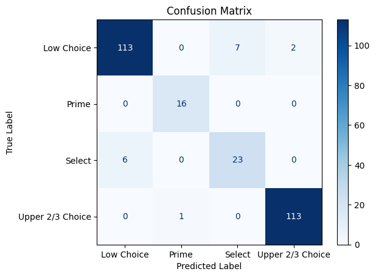

```python
cm = confusion_matrix(true_labels, predicted_classes)

# Plot confusion matrix
labels = list(validation_generator.class_indices.keys())
disp = ConfusionMatrixDisplay(confusion_matrix = cm, display_labels = labels)
disp.plot(cmap = plt.cm.Blues)
plt.title('Confusion Matrix')
plt.xlabel('Predicted Label')
plt.ylabel('True Label')
plt.show()
```

## Plot the accuracy and loss

Could probably benefit from more epochs but i value my computer's life

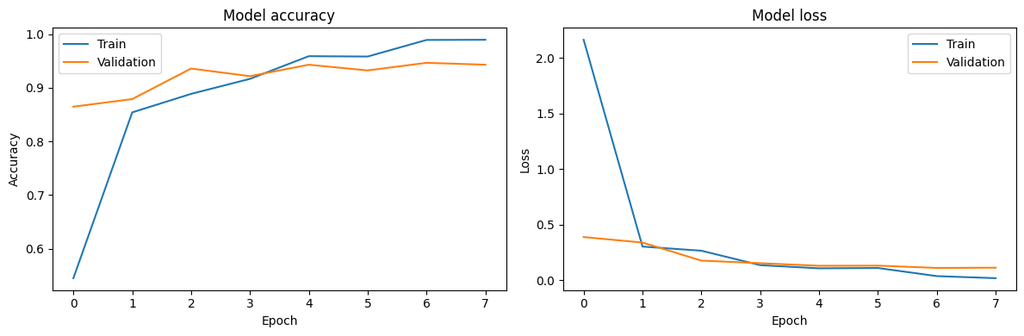

```python
plt.figure(figsize = (12, 4))
plt.subplot(1, 2, 1)
plt.plot(history.history['accuracy'])
plt.plot(history.history['val_accuracy'])
plt.title('Model accuracy')
plt.ylabel('Accuracy')
plt.xlabel('Epoch')
plt.legend(['Train', 'Validation'], loc = 'upper left')

plt.subplot(1, 2, 2)
plt.plot(history.history['loss'])
plt.plot(history.history['val_loss'])
plt.title('Model loss')
plt.ylabel('Loss')
plt.xlabel('Epoch')
plt.legend(['Train', 'Validation'], loc = 'upper right')

plt.tight_layout()
plt.show()
```

## Heatmap time

```
1/1 ━━━━━━━━━━━━━━━━━━━━ 0s 155ms/step
```

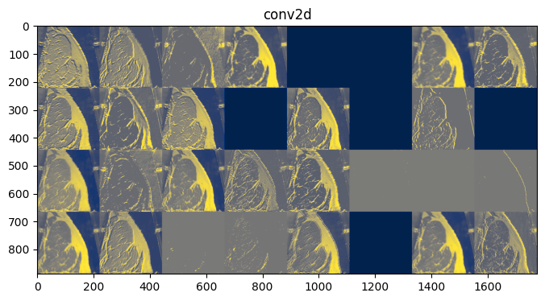

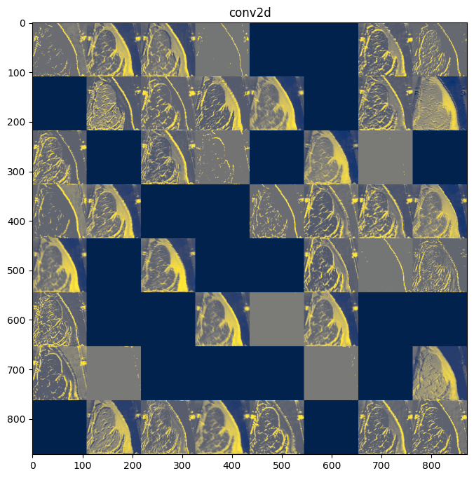

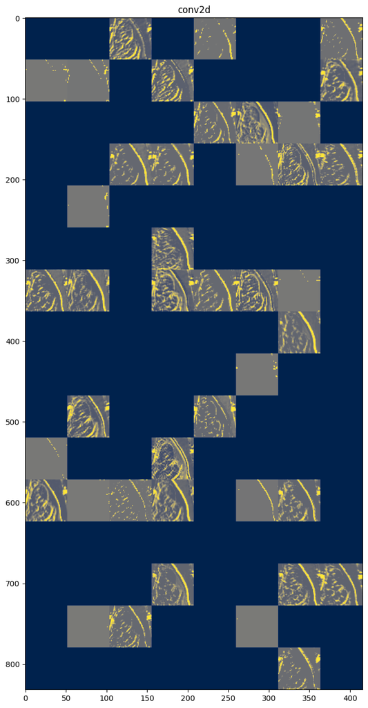

```python
img_array = img_to_array(img)
img_array /=  255.0

# this model holds the outputs for our original models layers
activation_model = Model(inputs = model.layers[0].input, outputs = [layer.output for layer in model.layers if 'conv2d' in layer.name])

# pulls the activations for the inputted image from each layer in our new model
activations = activation_model.predict(img_array.reshape(1, 224, 224, 3)) # we turn the image into a tensor so it can fit into the nn

# Plot the activations for each convolutional layer
for current_layer in activations:

    # pulls the size of the current layer to format grid
    n_features = current_layer.shape[-1]
    size = current_layer.shape[1]
    n_cols = n_features // 8
    display_grid = np.zeros((size * n_cols, 8 * size))

    for col in range(n_cols):
        for row in range(8):

            #extracts the current pattern in the layer
            channel_image = current_layer[0, :, :, col * 8 + row]

            #standardize and reshift images back to a 0-255 scale
            channel_image -=  channel_image.mean()
            channel_image /=  channel_image.std()
            channel_image *=  64
            channel_image +=  128
            channel_image = np.clip(channel_image, 0, 255).astype('uint8')

            #this adds each nodes image/pattern to the current grid
            display_grid[col * size : (col + 1) * size, row * size : (row + 1) * size] = channel_image

    scale = 1. / size
    plt.figure(figsize = (scale * display_grid.shape[1], scale * display_grid.shape[0]))
    plt.title("conv2d")
    plt.grid(False)
    plt.imshow(display_grid, aspect = 'auto', cmap = 'cividis')
    #other colors inferno, plasma, magma, bone

plt.show()
```

# How could this model be better?

One technique we spent a lot of time looking into was

### transfer learning.

Trasnfer learning is the use of implementing a pre-trained model from another task and repurposing it for new data. How could this be possible and where do I find it?

Resnet is the name of another model that has already been trained on millions of different photos. What would the benefit of this be?

The basic idea is that images can have the same basic patterns as others, and implementing a Resnet model in the beginning of your own would allow you to skip that basic pattern detection, and only focus on the larget patterns a CNN may need to detect for your new data.

Here's how you would setup code for incorporating a base model

```python
base_model = ResNet50(weights = 'imagenet', include_top = False, input_shape = (224, 224, 3))

# Here we freeze the layers inside of resnet. Meaning that they will not be retrained on our fit
for layer in base_model.layers:
    layer.trainable = False
```

```python
# Here we load the basemodel and add layers on top of it
model = Sequential([
    base_model,
    layers.Conv2D(64, (3, 3), activation = 'relu'),
    layers.MaxPooling2D((2, 2)),
    layers.GlobalAveragePooling2D(),
    layers.Dense(256, activation = 'relu'),
    layers.Dropout(0.5),
    layers.Dense(4, activation = 'softmax')
])

model.compile(optimizer = 'adam', loss = 'categorical_crossentropy', metrics = ['accuracy'])

model.summary()
```

```
Model: "sequential_6"
```

```
┏━━━━━━━━━━━━━━━━━━━━━━━━━━━━━━━━━┳━━━━━━━━━━━━━━━━━━━━━━━━┳━━━━━━━━━━━━━━━┓
┃ Layer (type)                    ┃ Output Shape           ┃       Param # ┃
┡━━━━━━━━━━━━━━━━━━━━━━━━━━━━━━━━━╇━━━━━━━━━━━━━━━━━━━━━━━━╇━━━━━━━━━━━━━━━┩
│ resnet50 (Functional)           │ ?                      │    23,587,712 │
├─────────────────────────────────┼────────────────────────┼───────────────┤
│ conv2d_16 (Conv2D)              │ ?                      │   0 (unbuilt) │
├─────────────────────────────────┼────────────────────────┼───────────────┤
│ max_pooling2d_11 (MaxPooling2D) │ ?                      │   0 (unbuilt) │
├─────────────────────────────────┼────────────────────────┼───────────────┤
│ global_average_pooling2d_1      │ ?                      │   0 (unbuilt) │
│ (GlobalAveragePooling2D)        │                        │               │
├─────────────────────────────────┼────────────────────────┼───────────────┤
│ dense_9 (Dense)                 │ ?                      │   0 (unbuilt) │
├─────────────────────────────────┼────────────────────────┼───────────────┤
│ dropout_6 (Dropout)             │ ?                      │             0 │
├─────────────────────────────────┼────────────────────────┼───────────────┤
│ dense_10 (Dense)                │ ?                      │   0 (unbuilt) │
└─────────────────────────────────┴────────────────────────┴───────────────┘
```

```
 Total params: 23,587,712 (89.98 MB)
```

```
 Trainable params: 0 (0.00 B)
```

```
 Non-trainable params: 23,587,712 (89.98 MB)
```

## Let's do regression on score

```python
train_generator_score = datagen.flow_from_dataframe(
    dataframe = train_data,
    directory = directory,
    x_col = 'Filename',
    y_col = 'Score',
    target_size = (224, 224),
    color_mode = 'rgb',
    batch_size = batch_size,
    class_mode = 'raw',
    shuffle = True
)

validation_generator_score = datagen.flow_from_dataframe(
    dataframe = validation_data,
    directory = directory,
    x_col = 'Filename',
    y_col = 'Score',
    target_size = (224, 224),
    color_mode = 'rgb',
    batch_size = batch_size,
    class_mode = 'raw',
    shuffle = False
)
```

```
Found 1120 validated image filenames.
Found 281 validated image filenames.
```

```python
model_score = Sequential()

model_score.add(Conv2D(32, (3, 3), activation = 'relu', input_shape = (224, 224, 3)))
model_score.add(MaxPooling2D((2, 2)))

model_score.add(Conv2D(64, (3, 3), activation = 'relu'))
model_score.add(MaxPooling2D((2, 2)))

model_score.add(Conv2D(128, (3, 3), activation = 'relu'))

model_score.add(Flatten())
model_score.add(Dropout(0.5))

model_score.add(Dense(256, activation = 'relu') )
model_score.add(Dense(1, activation = 'linear', name = 'Score'))
# change output layer to one, with linear activation
```

```python
model_score.compile(optimizer = 'Adam', loss = MeanSquaredError(), metrics = ['mae'])

checkpoint = ModelCheckpoint("coen_regression.keras", monitor = 'val_loss', verbose = 1, save_best_only = True, mode = 'min'
)
```

```python
# TTRAINNNN
score_history = model_score.fit(
    train_generator_score,
    epochs = 8,
    validation_data = validation_generator_score,
    callbacks = [checkpoint]
)
```

```
35/35 ━━━━━━━━━━━━━━━━━━━━ 0s 923ms/step - loss: 75057.7266 - mae: 209.5457
Epoch 1: val_loss improved from inf to 12549.88672, saving model to coen_regression.keras
35/35 ━━━━━━━━━━━━━━━━━━━━ 50s 1s/step - loss: 73917.4219 - mae: 207.4794 - val_loss: 12549.8867 - val_mae: 91.0044
35/35 ━━━━━━━━━━━━━━━━━━━━ 0s 1s/step - loss: 12525.1162 - mae: 88.2510
Epoch 2: val_loss improved from 12549.88672 to 10079.94922, saving model to coen_regression.keras
35/35 ━━━━━━━━━━━━━━━━━━━━ 54s 1s/step - loss: 12521.9971 - mae: 88.2151 - val_loss: 10079.9492 - val_mae: 79.7376
35/35 ━━━━━━━━━━━━━━━━━━━━ 0s 1s/step - loss: 11154.6025 - mae: 82.4667
Epoch 3: val_loss improved from 10079.94922 to 9718.77539, saving model to coen_regression.keras
35/35 ━━━━━━━━━━━━━━━━━━━━ 53s 1s/step - loss: 11150.5703 - mae: 82.4453 - val_loss: 9718.7754 - val_mae: 80.8360
35/35 ━━━━━━━━━━━━━━━━━━━━ 0s 1s/step - loss: 10435.8975 - mae: 81.2256
Epoch 4: val_loss improved from 9718.77539 to 9460.17090, saving model to coen_regression.keras
35/35 ━━━━━━━━━━━━━━━━━━━━ 54s 1s/step - loss: 10460.7607 - mae: 81.3064 - val_loss: 9460.1709 - val_mae: 80.1255
35/35 ━━━━━━━━━━━━━━━━━━━━ 0s 1s/step - loss: 10328.2305 - mae: 80.3212
Epoch 5: val_loss improved from 9460.17090 to 8095.65527, saving model to coen_regression.keras
35/35 ━━━━━━━━━━━━━━━━━━━━ 52s 1s/step - loss: 10336.4600 - mae: 80.3239 - val_loss: 8095.6553 - val_mae: 71.4298
35/35 ━━━━━━━━━━━━━━━━━━━━ 0s 1s/step - loss: 9491.8018 - mae: 76.3536
Epoch 6: val_loss did not improve from 8095.65527
35/35 ━━━━━━━━━━━━━━━━━━━━ 46s 1s/step - loss: 9494.9072 - mae: 76.3694 - val_loss: 10408.0078 - val_mae: 86.1160
35/35 ━━━━━━━━━━━━━━━━━━━━ 0s 1s/step - loss: 8884.6367 - mae: 74.6315
Epoch 7: val_loss improved from 8095.65527 to 7798.22412, saving model to coen_regression.keras
35/35 ━━━━━━━━━━━━━━━━━━━━ 53s 1s/step - loss: 8901.0557 - mae: 74.6943 - val_loss: 7798.2241 - val_mae: 71.4449
35/35 ━━━━━━━━━━━━━━━━━━━━ 0s 1s/step - loss: 8652.3506 - mae: 73.3495
Epoch 8: val_loss improved from 7798.22412 to 7477.49316, saving model to coen_regression.keras
35/35 ━━━━━━━━━━━━━━━━━━━━ 52s 1s/step - loss: 8652.0967 - mae: 73.3366 - val_loss: 7477.4932 - val_mae: 68.0459
```

```python
predicted_scores = model_score.predict(validation_generator_score)

lowest_score = np.min(predicted_scores)
highest_score = np.max(predicted_scores)

print(f"Lowest Score: {lowest_score}")
print(f"Highest Score: {highest_score}")
```

```
9/9 ━━━━━━━━━━━━━━━━━━━━ 3s 291ms/step
Lowest Score: 371.3567199707031
Highest Score: 568.480712890625
```